# Momentum experiment 26-Nov-2014

In this article, we pose the question: is RS6m (6 month relative) strenght a good predictor for the subsequent 6 months? The general conclusion is "yes", and we give a fuller explanation below.

## Running the model yourself

If anyone is interested in running these calculations themselves, then you will need IPython3 running together with various scientific packages. On Linux, you can install the necessary packages fairly readily. Windows users would be advised to obtain all the packages "in a oner" by downloading [Anaconda](http://continuum.io/downloads). If you are particularly interested in exploring this article further, then you can email me at `devnull at markcarter me uk`, and I will try to create more complete instructions.

Once you have IPython3 started, you will need to perform some standard imports:

```python
%matplotlib inline
import matplotlib.mlab as mlab
import matplotlib.pyplot as plt
import pylab
import numpy as np
import pandas as pd
```

Data is not generally available, but I have been able to get hold of some. Some preprocessing is required on my part:

```python
%%bash
DIR=~/Downloads
sh-csv < $DIR/StatsList.csv > $DIR/fixed.csv
csvtool namedcol epic,mkt,rs6mb,rs1y,rs5y $DIR/fixed.csv > $DIR/paste.csv
```

You will not be able to run the above commands yourself. I have made the processed data available at http://pastebin.com/raw.php?i=JWBf8LzF. This is loaded into a dataframe as follows:

```python
inp = pd.io.parsers.read_csv("http://pastebin.com/raw.php?i=JWBf8LzF")
print("The first few rows of the imported data:")
print(inp.head())
print("Some simple descriptive statistics of the data:")
print(inp.describe())
```

```
The first few rows of the imported data:
   epic       mkt  rs6mb   rs1y   rs5y
0   3IN   1322.84  10.00  14.31  17.29
1   888    484.86   9.01 -15.17   0.03
2   AA.   1941.45    NaN    NaN    NaN
3   AAL  18564.58 -14.44  -3.60 -60.58
4  ABBY    185.13  -1.87   0.73  67.17
Some simple descriptive statistics of the data:
                 mkt       rs6mb        rs1y         rs5y
count     682.000000  665.000000  642.000000   567.000000
mean     3540.309516   -0.182782    5.037695    78.360053
std     10758.853155   24.098168   37.449697   152.465873
min       100.050000  -73.580000  -79.600000   -93.880000
25%       219.112500  -11.590000  -13.160000    -7.795000
50%       597.470000   -0.110000    1.675000    41.360000
75%      1985.745000   10.040000   18.672500   113.680000
max    122129.400000  248.860000  377.180000  1185.910000
```

## Relative strengths

The data columns for a given company are as follows:

- mkt - the market value
- rs6mb - RS6m - relative strength for the last 6 months
- rs1y - relative strength for the last year
- rs5y - relative strength for last 5 years

Note that RS's are relative to the Footsie, rather than the market as a whole.

We want to compute to compute rs6ma - the relative strength in the period 6-12 months ago. Given rs6mb and rs1y, it is easily calculated:

```python
def rs6ma(rs6mb, rs1y):
    return  (rs1y/100.0 + 1.0)/(rs6mb/100.0 + 1.0)*100.0 - 100.0

def setup_data(raw):
    data = raw.copy()
    data = data.dropna(subset=["rs6mb","rs1y"])
    data['rs6ma'] = data.apply(lambda x: rs6ma(x['rs6mb'], x['rs1y']), axis=1)
    data = data[sorted(data.columns)]
    return data

data = setup_data(inp)
data.head()
```

|  | epic | mkt | rs1y | rs5y | rs6ma | rs6mb |
| --- | --- | --- | --- | --- | --- | --- |
| 0 | 3IN | 1322.84 | 14.31 | 17.29 | 3.918182 | 10.00 |
| 1 | 888 | 484.86 | -15.17 | 0.03 | -22.181451 | 9.01 |
| 3 | AAL | 18564.58 | -3.60 | -60.58 | 12.669472 | -14.44 |
| 4 | ABBY | 185.13 | 0.73 | 67.17 | 2.649547 | -1.87 |
| 5 | ABC | 846.97 | -10.13 | 81.83 | -22.499138 | 15.96 |

Let us look at how the relative strengths are distributed.

> **TODO**: investigate skew:
> - data.skew() measures skew, but I have yet to understand how to measure it.
> - $\chi^2$ is a test for distribution, which I also need to understand.

Here is a simple histogram plotting function:

```python
def hist(key, title):
    global data
    pylab.subplot(111, title = title)
    data[key].hist(bins = 100)
```

from which we can readily plot histograms:

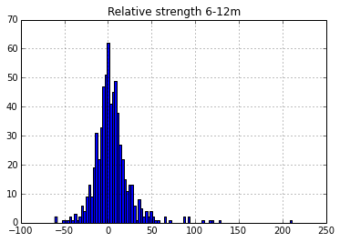

```python
hist('rs6ma', "Relative strength 6-12m")
```

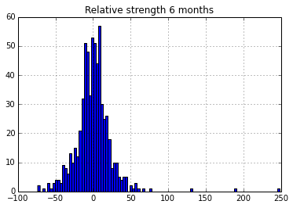

```python
hist('rs6mb', "Relative strength 6 months")
```

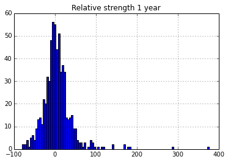

```python
hist('rs1y', "Relative strength 1 year")
```

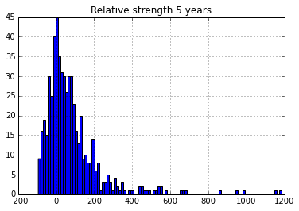

```python
hist('rs5y', "Relative strength 5 years")
```

It is clear that RS5y is skewed. Shares can lose at most 100%, whilst their upside is unlimited. Note that the data only shows results for companies that are listed currently, so there will be survivorship bias.

Let's see if we can spot a correlation between rs6ma and rs6mb:

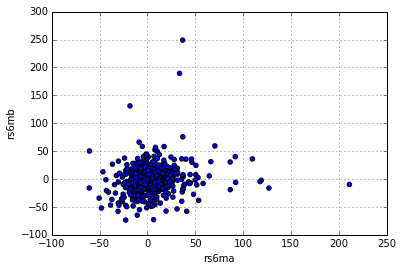

```python
data.plot(kind = 'scatter', x ='rs6ma', y = 'rs6mb' )
```

It seems that there *might* be a positive correlation between the two, although the correlation looks somewhat dubious. To get a better view, we should look at the Markov transition matrices under varying assumptions. This is the subject of the next section.

## Markov chain transition matrix

Let us remind ourselves of our objective: **to see if rs6ma (known) is a predictor for rs6mb**.

Markov chains are described in a [Wikipedia article](http://en.wikipedia.org/wiki/Markov_chain). Here, we divide the data into quintiles, with rows the rows representing rs6ma, and the columns rs6mb. We can then see the probabilities associated with the transitions.

Here is the code that allows us to do that:

```python
def quantile(column, quantile=5):
    "low q implies high value"
    q = pd.qcut(column, quantile)
    return len(q.levels)- q.labels

def markov(data, ntiles):
    #print("Num quantiles =", ntiles)
    aug = data.copy()
    aug['a'] = quantile(data['rs6ma'], ntiles)
    aug['b'] = quantile(data['rs6mb'], ntiles)
    #qtiles = quantiles(data, ntiles)
    m = np.zeros((ntiles, ntiles))
    for i, (qa, qb) in enumerate(zip(aug['a'].values, aug['b'].values)):
        m[qa-1][qb-1] += 1
    #print("Raw count:")
    #print(m)

    # normalise across rows
    row_sums = m.sum(axis=1)
    normed = m / row_sums[:, np.newaxis]

    # express in percentage terms
    f = np.vectorize(lambda x: round(x * 100, 1))
    nice = f(normed)
    print("Transition matrix (Q1 is top left)")
    print(nice)
    return aug, nice
```

The simplest form is:

```python
markov(data, 2) ;
```

```
Transition matrix (Q1 is top left)
[[ 52.  48.]
 [ 48.  52.]]
```

It shows that if you are in the top half of RS for 6 months, then you have a 52% chance of beating the market in the next 6 months. That advantage may seem slim, but a more encouraging pattern emerges if we split the data into quintiles:

```python
aug5, mark5 = markov(data, 5)
```

```
Transition matrix (Q1 is top left)
[[ 26.4  19.4  18.6  17.8  17.8]
 [ 15.6  24.2  23.4  23.4  13.3]
 [ 19.5  21.9  20.3  20.3  18. ]
 [ 21.1  17.2  22.7  18.8  20.3]
 [ 17.8  17.1  14.7  19.4  31. ]]
```

You can see that if you invested in the top quintile of relative strength, then you stand a disproportionate change of subsequently performing in the next top quintile (26.4%). Conversely, if you invested in the worst companies according to relative strength, then there is a 31% chance that you will underperform severly in the next 6 months.

Let's look at deciles:

```python
aug10, mark10 = markov(data, 10)
```

```
Transition matrix (Q1 is top left)
[[ 24.6   7.7   6.2   9.2   6.2   9.2  12.3   6.2   9.2   9.2]
 [  9.4  10.9  12.5  10.9  15.6   6.2   7.8   9.4  12.5   4.7]
 [  6.2  10.9   9.4  14.1  12.5  15.6   9.4   7.8  10.9   3.1]
 [  7.8   6.2  18.8   6.2   7.8  10.9   9.4  20.3   3.1   9.4]
 [  4.7  12.5  10.9  10.9   7.8   9.4  10.9   7.8  15.6   9.4]
 [  7.8  14.1   4.7  17.2  14.1   9.4   9.4  12.5   1.6   9.4]
 [ 12.5   9.4   9.4   4.7  18.8   9.4  10.9   7.8  12.5   4.7]
 [  9.4  10.9   7.8  12.5  10.9   6.2   9.4   9.4  14.1   9.4]
 [  9.4   9.4  12.5   9.4   4.7  15.6   7.8   7.8   9.4  14.1]
 [  9.2   7.7   7.7   4.6   1.5   7.7  12.3  10.8  10.8  27.7]]
```

**You can see that investing in the top decile gives you good odds of performing well, whilst investing in the bottom decile gives you a high probability of performing badly. Investing in other deciles gives results that are more mixed.**

We can computer the probabilities of outperforming the market given an initial decile:

```python
print("Probability of outperforming:")
for i, row in enumerate(mark10):
    print("Decile ", i+1, ":", sum(row[0:5]))
```

```
Probability of outperforming:
Decile  1 : 53.9
Decile  2 : 59.3
Decile  3 : 53.1
Decile  4 : 46.8
Decile  5 : 46.8
Decile  6 : 57.9
Decile  7 : 54.8
Decile  8 : 51.5
Decile  9 : 45.4
Decile  10 : 30.7
```

Decile 2 gives you the best chance of outperforming; but remember, when you do outperforming in decile 1, you are likely to outperform better.

The threshold of the deciles are as follows:

```python
grp10 = aug10.groupby('a')
limits = pd.DataFrame()
limits['min'] = grp10.min()['rs6ma']
limits['max'] = grp10.max()['rs6ma']
limits
```

| a | min | max |
| --- | --- | --- |
| 1 | 25.441413 | 211.040905 |
| 2 | 14.703962 | 25.132950 |
| 3 | 9.634187 | 14.664012 |
| 4 | 5.873245 | 9.609895 |
| 5 | 1.783061 | 5.674244 |
| 6 | -1.172116 | 1.756429 |
| 7 | -4.344779 | -1.172529 |
| 8 | -8.958437 | -4.370502 |
| 9 | -15.603024 | -9.009376 |
| 10 | -60.836411 | -15.604508 |

We can also see the shares that performed the best over th two 6-month periods:

```python
aug10[(aug10['a'] == 1) & (aug10['b'] == 1)]
```

|  | epic | mkt | rs1y | rs5y | rs6ma | rs6mb | a | b |
| --- | --- | --- | --- | --- | --- | --- | --- | --- |
| 19 | AHT | 5289.43 | 57.73 | 1154.87 | 28.277489 | 22.96 | 1 | 1 |
| 216 | FLOW | 113.75 | 171.52 | -21.12 | 70.445700 | 59.30 | 1 | 1 |
| 255 | GOG | 1117.35 | 59.29 | 57.76 | 27.892413 | 24.55 | 1 | 1 |
| 263 | GWP | 1012.90 | 143.12 | 271.81 | 86.427421 | 30.41 | 1 | 1 |
| 265 | HCM | 776.42 | 140.57 | 460.04 | 36.967661 | 75.64 | 1 | 1 |
| 355 | LGO | 109.48 | 377.18 | -14.34 | 36.782664 | 248.86 | 1 | 1 |
| 380 | MEC | 166.07 | 90.16 | -10.69 | 46.412073 | 29.88 | 1 | 1 |
| 446 | PDL | 1056.34 | 89.99 | 156.93 | 40.120953 | 35.59 | 1 | 1 |
| 469 | POWR | 150.58 | 84.96 | 39.65 | 35.760423 | 36.24 | 1 | 1 |
| 513 | RNWH | 179.88 | 87.41 | 539.83 | 50.614804 | 24.43 | 1 | 1 |
| 528 | RXP | 116.75 | 286.48 | 20.44 | 33.554496 | 189.38 | 1 | 1 |
| 534 | SBD | 2487.65 | 117.86 | 70.58 | 66.254579 | 31.04 | 1 | 1 |
| 557 | SIG | 6622.91 | 72.71 | 316.57 | 27.942811 | 34.99 | 1 | 1 |
| 561 | SKP | 353.22 | 185.27 | 181.26 | 109.695678 | 36.04 | 1 | 1 |
| 579 | SPRP | 153.57 | 168.55 | 954.92 | 91.766638 | 40.04 | 1 | 1 |
| 624 | TRCS | 106.49 | 98.19 | 512.59 | 46.017830 | 35.73 | 1 | 1 |

## Questions for follow-up

It will be interesting to try to investigate the following questions:

- What is the expected return on investing in each decile?
- How does it vary over time?
- How does short-term momentum correlate with the 5 year relative strength? If you think that that there is mean-reversion in momentum over the long term, could it be that you can improve your returns in the top short-run decile by looking for stocks that had also performed poorly over 5 years?
- If I picked on one company, and looked at returns over 6, 12, 18, 24, ... returns, is there any insights that could be obtained? For example, could combining high relative 6 AND 12 month returns improve one's odds?

## About this document

```
Created: 26-Nov-2014
Updated: 05-Dec-2014
```